# W3cubDocs

/scikit-learn

# sklearn.svm.SVC

**`class sklearn.svm.SVC(C=1.0, kernel=’rbf’, degree=3, gamma=’auto_deprecated’, coef0=0.0, shrinking=True, probability=False, tol=0.001, cache_size=200, class_weight=None, verbose=False, max_iter=-1, decision_function_shape=’ovr’, random_state=None)` [[source]](https://github.com/scikit-learn/scikit-learn/blob/bac89c2/sklearn/svm/classes.py#L429)**

C-Support Vector Classification.

The implementation is based on libsvm. The fit time complexity is more than quadratic with the number of samples which makes it hard to scale to dataset with more than a couple of 10000 samples.

The multiclass support is handled according to a one-vs-one scheme.

For details on the precise mathematical formulation of the provided kernel functions and how `gamma`, `coef0` and `degree` affect each other, see the corresponding section in the narrative documentation: Kernel functions.

Read more in the User Guide.

[output not shown]

See also

**`SVR`**

Support Vector Machine for Regression implemented using libsvm.

**`LinearSVC`**

Scalable Linear Support Vector Machine for classification implemented using liblinear. Check the See also section of LinearSVC for more comparison element.

#### Examples

```
>>> import numpy as np
>>> X = np.array([[-1, -1], [-2, -1], [1, 1], [2, 1]])
>>> y = np.array([1, 1, 2, 2])
>>> from sklearn.svm import SVC
>>> clf = SVC(gamma='auto')
>>> clf.fit(X, y)
SVC(C=1.0, cache_size=200, class_weight=None, coef0=0.0,
    decision_function_shape='ovr', degree=3, gamma='auto', kernel='rbf',
    max_iter=-1, probability=False, random_state=None, shrinking=True,
    tol=0.001, verbose=False)
>>> print(clf.predict([[-0.8, -1]]))
[1]
```

#### Methods

| `decision_function`(X) | Distance of the samples X to the separating hyperplane. |
| --- | --- |
| `fit`(X, y[, sample_weight]) | Fit the SVM model according to the given training data. |
| `get_params`([deep]) | Get parameters for this estimator. |
| `predict`(X) | Perform classification on samples in X. |
| `score`(X, y[, sample_weight]) | Returns the mean accuracy on the given test data and labels. |
| `set_params`(**params) | Set the parameters of this estimator. |

**`__init__(C=1.0, kernel=’rbf’, degree=3, gamma=’auto_deprecated’, coef0=0.0, shrinking=True, probability=False, tol=0.001, cache_size=200, class_weight=None, verbose=False, max_iter=-1, decision_function_shape=’ovr’, random_state=None)` [[source]](https://github.com/scikit-learn/scikit-learn/blob/bac89c2/sklearn/svm/classes.py#L585)**

**`decision_function(X)` [[source]](https://github.com/scikit-learn/scikit-learn/blob/bac89c2/sklearn/svm/base.py#L531)**

Distance of the samples X to the separating hyperplane.

[output not shown]

**`fit(X, y, sample_weight=None)` [[source]](https://github.com/scikit-learn/scikit-learn/blob/bac89c2/sklearn/svm/base.py#L108)**

Fit the SVM model according to the given training data.

[output not shown]

#### Notes

If X and y are not C-ordered and contiguous arrays of np.float64 and X is not a scipy.sparse.csr_matrix, X and/or y may be copied.

If X is a dense array, then the other methods will not support sparse matrices as input.

**`get_params(deep=True)` [[source]](https://github.com/scikit-learn/scikit-learn/blob/bac89c2/sklearn/base.py#L166)**

Get parameters for this estimator.

| Parameters: | **`deep : boolean, optional`** If True, will return the parameters for this estimator and contained subobjects that are estimators. |
| --- | --- |
| Returns: | **`params : mapping of string to any`** Parameter names mapped to their values. |

**`predict(X)` [[source]](https://github.com/scikit-learn/scikit-learn/blob/bac89c2/sklearn/svm/base.py#L551)**

Perform classification on samples in X.

For an one-class model, +1 or -1 is returned.

| Parameters: | **`X : {array-like, sparse matrix}, shape (n_samples, n_features)`** For kernel=”precomputed”, the expected shape of X is [n_samples_test, n_samples_train] |
| --- | --- |
| Returns: | **`y_pred : array, shape (n_samples,)`** Class labels for samples in X. |

**`predict_log_proba`**

Compute log probabilities of possible outcomes for samples in X.

The model need to have probability information computed at training time: fit with attribute `probability` set to True.

[output not shown]

#### Notes

The probability model is created using cross validation, so the results can be slightly different than those obtained by predict. Also, it will produce meaningless results on very small datasets.

**`predict_proba`**

Compute probabilities of possible outcomes for samples in X.

The model need to have probability information computed at training time: fit with attribute `probability` set to True.

[output not shown]

#### Notes

The probability model is created using cross validation, so the results can be slightly different than those obtained by predict. Also, it will produce meaningless results on very small datasets.

**`score(X, y, sample_weight=None)` [[source]](https://github.com/scikit-learn/scikit-learn/blob/bac89c2/sklearn/base.py#L263)**

Returns the mean accuracy on the given test data and labels.

In multi-label classification, this is the subset accuracy which is a harsh metric since you require for each sample that each label set be correctly predicted.

[output not shown]

**`set_params(**params)` [[source]](https://github.com/scikit-learn/scikit-learn/blob/bac89c2/sklearn/base.py#L189)**

Set the parameters of this estimator.

The method works on simple estimators as well as on nested objects (such as pipelines). The latter have parameters of the form `<component>__<parameter>` so that it’s possible to update each component of a nested object.

| Returns: | **self** |
| --- | --- |

## Examples using `sklearn.svm.SVC`

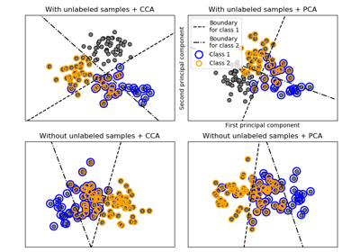

Multilabel classification

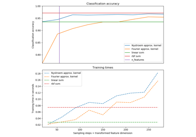

Explicit feature map approximation for RBF kernels

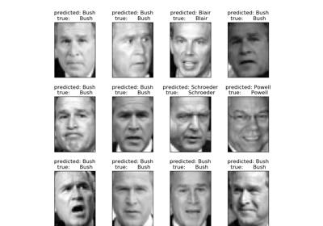

Faces recognition example using eigenfaces and SVMs

Libsvm GUI

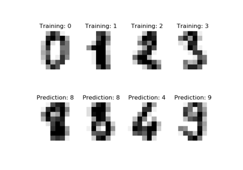

Recognizing hand-written digits

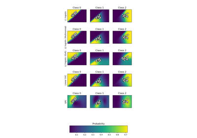

Plot classification probability

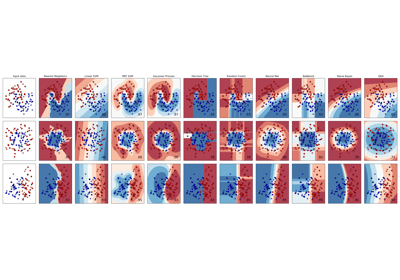

Classifier comparison

Concatenating multiple feature extraction methods

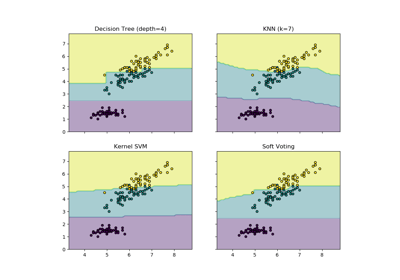

Plot the decision boundaries of a VotingClassifier

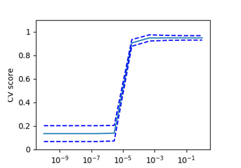

Cross-validation on Digits Dataset Exercise

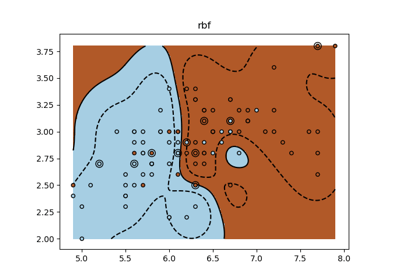

SVM Exercise

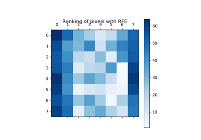

Recursive feature elimination

Pipeline Anova SVM

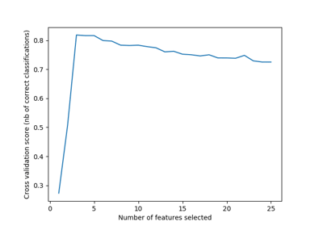

Recursive feature elimination with cross-validation

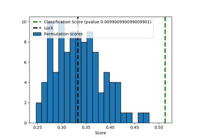

Test with permutations the significance of a classification score

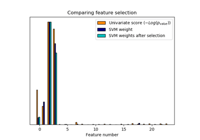

Univariate Feature Selection

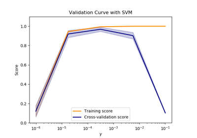

Plotting Validation Curves

Parameter estimation using grid search with cross-validation

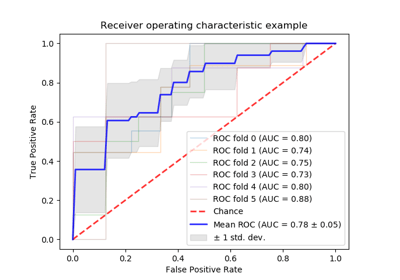

Receiver Operating Characteristic (ROC) with cross validation

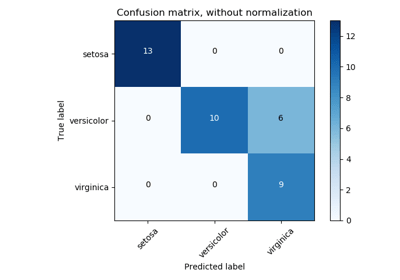

Confusion matrix

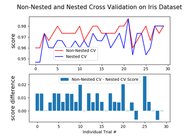

Nested versus non-nested cross-validation

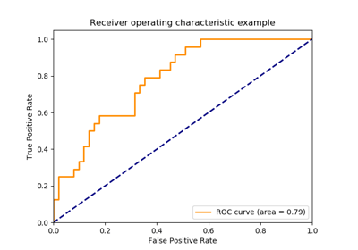

Receiver Operating Characteristic (ROC)

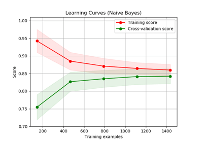

Plotting Learning Curves

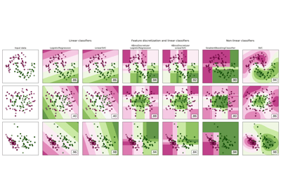

Feature discretization

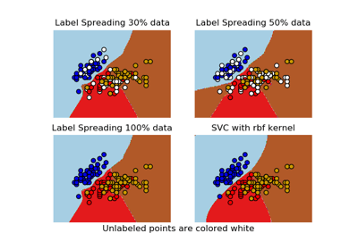

Decision boundary of label propagation versus SVM on the Iris dataset

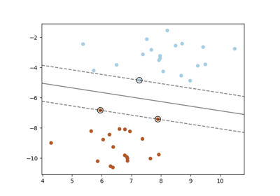

SVM: Maximum margin separating hyperplane

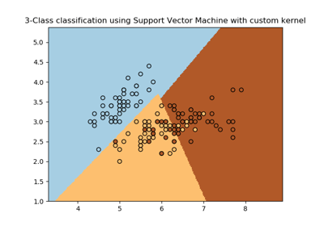

SVM with custom kernel

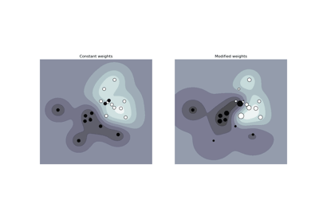

SVM: Weighted samples

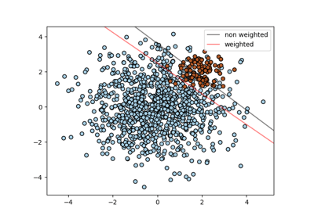

SVM: Separating hyperplane for unbalanced classes

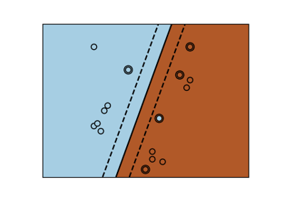

SVM-Kernels

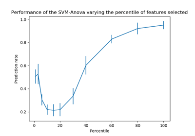

SVM-Anova: SVM with univariate feature selection

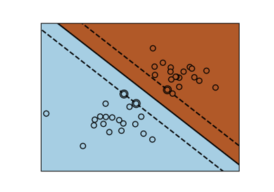

SVM Margins Example

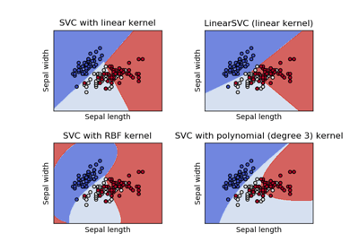

Plot different SVM classifiers in the iris dataset

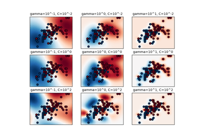

RBF SVM parameters

© 2007–2018 The scikit-learn developers  
Licensed under the 3-clause BSD License.  
http://scikit-learn.org/stable/modules/generated/sklearn.svm.SVC.html